# Sentiment Analysis pour des tweets :

Ce document explore plusieurs méthodes qui permettent de prédire le sentiment général des tweets et les classifier en 3 classes : Négatif, Neutre et Positif.

On peut adapter ce traitement à des articles en francais. On peut entraîner un modèle sur un langage similaire à celui présent dans les revues de presse.

On peut aussi utiliser des méthodes de Deep Learning (deep convolutional neural networks), même si ce genre de modèle a une mauvaise performance s'il est entraîné sur un petit nombre d'observations.

```python
import numpy as np
import nltk
nltk.download('punkt')
import pandas as pd
import matplotlib .pyplot as plt
```

# Récupération des données

### Train

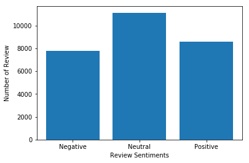

```python
path=r'C:/Users/Nicole/Desktop/Stage code/Dataset/train.csv'
df_train=pd.read_csv(path)
df_train['sentiment'].replace({'neutral':0,'positive':1,'negative':-1},inplace=True)

#compte nombre sentiment positif, negatif , neutre
df_train['sentiment'].value_counts()

# graphqiue sentiment
Sentiment_count=df_train.groupby('sentiment').count()
plt.bar(Sentiment_count.index.values, Sentiment_count['selected_text'])
plt.xlabel('Review Sentiments')
plt.ylabel('Number of Review')
plt.xticks([-1,0,1], ["Negative","Neutral", "Positive"])
plt.show()
```

```python
df_train.head(10)
```

|  | textID | text | selected_text | sentiment |
| --- | --- | --- | --- | --- |
| 0 | cb774db0d1 | I`d have responded, if I were going | I`d have responded, if I were going | 0 |
| 1 | 549e992a42 | Sooo SAD I will miss you here in San Diego!!! | Sooo SAD | -1 |
| 2 | 088c60f138 | my boss is bullying me... | bullying me | -1 |
| 3 | 9642c003ef | what interview! leave me alone | leave me alone | -1 |
| 4 | 358bd9e861 | Sons of ****, why couldn`t they put them on t... | Sons of ****, | -1 |
| 5 | 28b57f3990 | http://www.dothebouncy.com/smf - some shameles... | http://www.dothebouncy.com/smf - some shameles... | 0 |
| 6 | 6e0c6d75b1 | 2am feedings for the baby are fun when he is a... | fun | 1 |
| 7 | 50e14c0bb8 | Soooo high | Soooo high | 0 |
| 8 | e050245fbd | Both of you | Both of you | 0 |
| 9 | fc2cbefa9d | Journey!? Wow... u just became cooler. hehe.... | Wow... u just became cooler. | 1 |

### Test

```python
path=r'C:/Users/Nicole/Desktop/Stage code/Dataset/test.csv'
df_test=pd.read_csv(path)
df_test['sentiment'].replace({'neutral':0,'positive':1,'negative':-1},inplace=True)

nb_test=df_test.shape[0]
```

### Frequency Analysis

```python
#On montre les 100 mots les plus fréquents dans le train Set
```

[output not shown]

```python
df=pd.concat((df_train,df_test))

#renommer indice
df.selected_text[df.selected_text.isna()]=df.text
df.reset_index(inplace=True)
df.drop('index',axis=1,inplace=True)
df.head(10)
```

|  | selected_text | sentiment | text | textID |
| --- | --- | --- | --- | --- |
| 0 | I`d have responded, if I were going | 0 | I`d have responded, if I were going | cb774db0d1 |
| 1 | Sooo SAD | -1 | Sooo SAD I will miss you here in San Diego!!! | 549e992a42 |
| 2 | bullying me | -1 | my boss is bullying me... | 088c60f138 |
| 3 | leave me alone | -1 | what interview! leave me alone | 9642c003ef |
| 4 | Sons of ****, | -1 | Sons of ****, why couldn`t they put them on t... | 358bd9e861 |
| 5 | http://www.dothebouncy.com/smf - some shameles... | 0 | http://www.dothebouncy.com/smf - some shameles... | 28b57f3990 |
| 6 | fun | 1 | 2am feedings for the baby are fun when he is a... | 6e0c6d75b1 |
| 7 | Soooo high | 0 | Soooo high | 50e14c0bb8 |
| 8 | Both of you | 0 | Both of you | e050245fbd |
| 9 | Wow... u just became cooler. | 1 | Journey!? Wow... u just became cooler. hehe.... | fc2cbefa9d |

# Pre-processing

```python
from nltk.corpus import stopwords
from nltk.stem import WordNetLemmatizer
from nltk.stem.porter import PorterStemmer
nltk.download('wordnet')
```

```
True
```

```python
df.dtypes
```

```
selected_text    object
sentiment         int64
text             object
textID           object
dtype: object
```

```python
# conversion des float en string
df['selected_text']=df['selected_text'].apply(lambda x: str(x))

# conversion en minuscule
df['selected_text']=df['selected_text'].apply(lambda x: str.lower(x))

#stopwords
stop = stopwords.words('english')
df['selected_text'].apply(lambda x: [item for item in x if item not in stop])
df.head(5)
```

|  | selected_text | sentiment | text | textID |
| --- | --- | --- | --- | --- |
| 0 | i`d have responded, if i were going | 0 | I`d have responded, if I were going | cb774db0d1 |
| 1 | sooo sad | -1 | Sooo SAD I will miss you here in San Diego!!! | 549e992a42 |
| 2 | bullying me | -1 | my boss is bullying me... | 088c60f138 |
| 3 | leave me alone | -1 | what interview! leave me alone | 9642c003ef |
| 4 | sons of ****, | -1 | Sons of ****, why couldn`t they put them on t... | 358bd9e861 |

### Lemmatization

Lemmatization est une autre technique plus populaire avec plusieurs modèles pré-entraînés. (WordNet disponible sur nltk)

```python
wordnet_lemmatizer = WordNetLemmatizer()
nrows = len(df)
lemmatized_text_list = []
tokenizer = nltk.RegexpTokenizer(r"\w+")

for row in range(0, nrows):
   # Save the text and its words into an object
    text = str(df.loc[row]['text'])
    text = text.lower()
    text.strip()
    text_words = tokenizer.tokenize(text)
    text_words=[word for word in text_words if word not in stop]
    text_words=[word for word in text_words if '@' not in word]
    text_words=[word for word in text_words if '#' not in word]
    text_words=[word for word in text_words if 'http' not in word]
    lemmatized_text=" ".join([wordnet_lemmatizer.lemmatize(word, pos="v") for word in text_words])

    # Append to the list containing the texts
    lemmatized_text_list.append(lemmatized_text)
```

```python
df['lemmas'] = lemmatized_text_list
df.head(5)
```

|  | selected_text | sentiment | text | textID | lemmas |
| --- | --- | --- | --- | --- | --- |
| 0 | i`d have responded, if i were going | 0 | I`d have responded, if I were going | cb774db0d1 | respond go |
| 1 | sooo sad | -1 | Sooo SAD I will miss you here in San Diego!!! | 549e992a42 | sooo sad miss san diego |
| 2 | bullying me | -1 | my boss is bullying me... | 088c60f138 | boss bully |
| 3 | leave me alone | -1 | what interview! leave me alone | 9642c003ef | interview leave alone |
| 4 | sons of ****, | -1 | Sons of ****, why couldn`t they put them on t... | 358bd9e861 | sons put release already buy |

# Text representation

```python
from sklearn.model_selection import train_test_split
from sklearn.feature_extraction.text import TfidfTransformer, CountVectorizer
from sklearn.pipeline import make_pipeline
```

### TF-IDF vectors

$$ TFIDF(t,d)=TF(t,d)log(\frac{N}{DF(t)})$$$$ TF(t,d) = \frac{Nombre~d'apparition~de~ t~ dans~ d}{nombre~ total~ de~ mots~ dans~ d}$$$$ DF(t) = nombre~ de~ documents~ contenant ~t$$

```python
X_train, X_test, y_train, y_test = train_test_split(df[["lemmas"]], df['sentiment'], test_size=nb_test, shuffle=False)

pipe = make_pipeline(CountVectorizer(), TfidfTransformer())

pipe.fit(X_train['lemmas'])

feat_train_tfidf = pipe.transform(X_train['lemmas'])

feat_test_tfidf = pipe.transform(X_test['lemmas'])
```

### Word embeddings

C'est une représentation apprise d'un texte où les mots qui ont la même signification ont une représentation similaire. $f(d)$ est un représentant de $d$ dans un nouvel espace, le choix de ce nouvel espace est effectué de telle sorte à ce que $f(d)$ ne soit pas "sparse".

""The distributed representation is learned based on the usage of words. This allows words that are used in similar ways to result in having similar representations, naturally capturing their meaning.""

Le fait qu'un grand nombre de tweets dans cet exercice comporte plusieurs fautes d'orthographe (donc plusieurs irrégularités pour les mots) rendera l'apprentissage du word embedding plus difficile.

Pour entraîner le word embedding, on a deux approches possibles, la première est le CBOW qui cherche à apprendre l'entourage à partir du mot, la deuxième est le Skip-gram et consiste à apprendre le mot à travers son entourage.

on utilise word2Vec : https://pathmind.com/wiki/word2vec#:~:text=Word2vec%20is%20a%20two%2Dlayer,deep%20neural%20networks%20can%20understand.

### Entrainer le Word2Vec

On va entraîner le Word2Vec en utilisant une base de données que j'ai trouvé sur internet contenant 1.6 millions tweets, cela servira seulement comme exemple illustratif ce que l'on peut faire avec cet outil.

```python
import gensim
from gensim.models.word2vec import Word2Vec
```

```python
path=r'C:/Users/Nicole/Desktop/Stage code/Dataset/tweets.csv'
extra_tweets=pd.read_csv(path,encoding='latin-1',usecols=[5])
extra_tweets.columns = ['tweet']
extra_tweets.head(5)
```

|  | tweet |
| --- | --- |
| 0 | is upset that he can't update his Facebook by ... |
| 1 | @Kenichan I dived many times for the ball. Man... |
| 2 | my whole body feels itchy and like its on fire |
| 3 | @nationwideclass no, it's not behaving at all.... |
| 4 | @Kwesidei not the whole crew |

```python
#preprocessing
sentences=list(extra_tweets.tweet)
tokenizer = nltk.RegexpTokenizer(r"\w+")

for i in range(len(sentences)) :
    s=str(sentences[i])
    s=s.lower()
    s.strip() #remove extra whitespaces
    s=[word for word in s.split(' ') if word not in stop] #on enleve les stopwords et on transforme la liste en string
    s=[word for word in s if '@' not in word]
    s=[word for word in s if '#' not in word]
    s=[word for word in s if 'http' not in word]
    s=[word for word in s if word!='']
    s=" ".join([wordnet_lemmatizer.lemmatize(word, pos="v") for word in s])
    s = tokenizer.tokenize(s)
    sentences[i]=s
```

```python
#notre propre word embedding
#Skip-gram
size_=50
model = Word2Vec(sentences, min_count=1,size=size_,workers=3, window =3, sg = 1) #sg={0,1} 1=skip-ram 0=CBOW
```

```python
tweets=[ " ".join(s) for s in sentences]
```

### Resultats

On montre quelques résultats du modèle. Most_similar(x) nous donne les mots les plus similaire à x (qui ont une représentation vectorielle colinéaire à x), et le chiffre affiché devant représente la similarité entre les deux mots.

```python
model.most_similar('good')
```

```
[('great', 0.9254820346832275),
 ('goooooood', 0.8931527733802795),
 ('terrific', 0.8831398487091064),
 ('gooooood', 0.8802332878112793),
 ('gooood', 0.8796131610870361),
 ('goood', 0.8783054351806641),
 ('bad', 0.8772755861282349),
 ('gooooooood', 0.8758019804954529),
 ('stellar', 0.8749985098838806),
 ('excellent', 0.8719643354415894)]
```

```python
model.most_similar('work')
```

```
[('playtime', 0.9140619039535522),
 ('coding', 0.9074171185493469),
 ('yardwork', 0.9066699743270874),
 ('ion', 0.9055742025375366),
 ('inventory', 0.9038882255554199),
 ('tmrrw', 0.903285026550293),
 ('supposed', 0.9022617340087891),
 ('payroll', 0.9015198945999146),
 ('raring', 0.9008148908615112),
 ('arrgh', 0.9007717967033386)]
```

```python
model.most_similar('unemployed')
```

```
[('jobless', 0.9054509401321411),
 ('employed', 0.8767931461334229),
 ('wiser', 0.873898983001709),
 ('jobs', 0.8698155283927917),
 ('searching', 0.8631892800331116),
 ('uncertain', 0.861943781375885),
 ('destine', 0.861881673336029),
 ('surpass', 0.8591331243515015),
 ('costly', 0.8547298312187195),
 ('salary', 0.8532676696777344)]
```

```python
model.most_similar('crisis')
```

```
[('balance', 0.8680872917175293),
 ('economic', 0.8565216660499573),
 ('secure', 0.8518709540367126),
 ('unacceptable', 0.8407317996025085),
 ('midlife', 0.8397399187088013),
 ('vital', 0.8375565409660339),
 ('necessity', 0.8373643755912781),
 ('budget', 0.833426833152771),
 ('cases', 0.8315607309341431),
 ('path', 0.8310593366622925)]
```

```python
model.most_similar('kid')
```

```
[('kids', 0.9399262070655823),
 ('teenagers', 0.9118236303329468),
 ('boys', 0.9095584154129028),
 ('suckers', 0.8988864421844482),
 ('housemates', 0.8953855037689209),
 ('siblings', 0.8952463269233704),
 ('2yo', 0.8952117562294006),
 ('son', 0.8899869918823242),
 ('child', 0.8893116116523743),
 ('toddlers', 0.8882834911346436)]
```

```python
model['kid']
```

```
array([ 0.44233707,  0.06100756, -0.88066363,  0.45618507, -0.763402  ,
       -0.24439734, -0.0382711 , -0.19758007, -0.33114138, -0.66724676,
        0.8644114 ,  0.3487497 ,  1.0296803 , -0.51522696,  0.22731455,
        0.3598713 , -0.23970656,  0.49413785,  0.06727351,  0.35811257,
        0.4922897 , -0.5827337 ,  0.18138467,  0.4743569 ,  0.02494274,
        0.34519562, -0.2793239 , -0.5504956 ,  0.8103825 , -0.23921993,
       -0.1265511 ,  0.10301951,  0.27694997,  0.4256043 ,  0.19632806,
       -0.39809114, -0.44074848,  0.70989454,  0.05473602,  0.39817765,
       -0.9786934 ,  0.2090047 ,  0.4259141 , -0.4072286 , -0.3567006 ,
       -0.14314134, -0.5562298 , -0.23608492,  0.30399588,  0.23739026],
      dtype=float32)
```

# Feature Engineering

### Poids = TfIdf

Avec le modèle de Word Embedding, chaque mot est représenté par un vecteur $x=(x_1,...,x_n)$, donc pour représenter une phrase on peut combiner linéairement tout ces vecteurs à l'aide de certains poids.

Si on prend comme poids $poids= \frac{1}{longueur~ de~ la~ phrase}$, 'the' aura le même apport qu'un autre mot plus significatif. Si on prend comme poids les score TD-IDF on va favoriser les mots qui ont moins d'occurences.

Afin d'utiliser les TD-IDF de facon efficace, on va créer une matrice 2D.

```python
cv=CountVectorizer()
#le vocabulaire était celui du train avec cette commande ce qui crééer des problèmes avec avec le word embedding par la suite
#word_count_vector=cv.fit_transform(list(X_train['lemmas']))
word_count_vector=cv.fit_transform(tweets)

count_vector=cv.transform(list(X_train['lemmas']))
tfidf_transformer=TfidfTransformer(smooth_idf=True,use_idf=True)
tfidf_transformer.fit(word_count_vector)
tf_idf_matrix=tfidf_transformer.transform(count_vector)
```

```python
print(tf_idf_matrix[0])
print(tf_idf_matrix[0].data)
```

```
  (0, 200418)	0.9291529381693965
  (0, 100031)	0.36969557407572173
[0.92915294 0.36969557]
```

```python
feat_train=[]
for i in range(X_train.shape[0]):
    arr=np.zeros(size_)
    sentence=X_train.iloc[i].lemmas
    words=sentence.split(' ')
    weights=tf_idf_matrix[i].data
    words=list(dict.fromkeys(words))
    k=0
    for j in range(len(words)):
        if words[j] in model.wv.vocab and len(words[j])>1:
            arr+= model[words[j]]*weights[k]
            k+=1
    feat_train.append(arr)
```

```python
count_vector_test=cv.transform(list(X_test['lemmas']))
tf_idf_matrix_test=tfidf_transformer.transform(count_vector_test)

feat_test=[]
for i in range(X_test.shape[0]):
    arr=np.zeros(size_)
    sentence=X_test.iloc[i].lemmas
    words=sentence.split(' ')
    weights=tf_idf_matrix_test[i].data
    words=list(dict.fromkeys(words))
    k=0
    for j in range(len(words)):
        if words[j] in model.wv.vocab and len(words[j])>1:
            arr+= model[words[j]]*weights[k]
            k+=1

    feat_test.append(arr)
```

### Entrainement du modèle de prédiction

```python
from sklearn.ensemble import RandomForestClassifier
from sklearn.metrics import confusion_matrix
from sklearn.metrics import classification_report
from sklearn.linear_model import LogisticRegression
from sklearn.neighbors import KNeighborsClassifier
from sklearn.svm import SVC
```

```python
#Random Forest

clf = RandomForestClassifier(n_estimators=50,max_depth=15,bootstrap=True,random_state=1,criterion='entropy')
clf.fit(feat_train, y_train)

predicted=clf.predict(feat_test)
```

```python
print(confusion_matrix(y_test, predicted))
target_names = ['class -1', 'class 0', 'class 1']
print(classification_report(y_test, predicted, target_names=target_names))
```

```
[[485 410 106]
 [226 969 235]
 [ 95 360 648]]
              precision    recall  f1-score   support

    class -1       0.60      0.48      0.54      1001
     class 0       0.56      0.68      0.61      1430
     class 1       0.66      0.59      0.62      1103

   micro avg       0.59      0.59      0.59      3534
   macro avg       0.60      0.58      0.59      3534
weighted avg       0.60      0.59      0.59      3534
```

```python
#logistic Regression
clf = LogisticRegression(random_state=3, penalty ='l1',C=0.05)
clf.fit(feat_train, y_train)

predicted=clf.predict(feat_test)
```

```python
print(confusion_matrix(y_test, predicted))
target_names = ['class -1', 'class 0', 'class 1']
print(classification_report(y_test, predicted, target_names=target_names))
```

```
[[ 561  352   88]
 [ 218 1006  206]
 [ 106  291  706]]
              precision    recall  f1-score   support

    class -1       0.63      0.56      0.59      1001
     class 0       0.61      0.70      0.65      1430
     class 1       0.71      0.64      0.67      1103

   micro avg       0.64      0.64      0.64      3534
   macro avg       0.65      0.63      0.64      3534
weighted avg       0.65      0.64      0.64      3534
```

```python
#SVM avec noyau RBF
clf = SVC(C=10,kernel='rbf')
clf.fit(feat_train, y_train)

predicted=clf.predict(feat_test)
```

```python
print(confusion_matrix(y_test, predicted))
target_names = ['class -1', 'class 0', 'class 1']
print(classification_report(y_test, predicted, target_names=target_names))
```

```
[[ 575  368   58]
 [ 198 1033  199]
 [  91  320  692]]
              precision    recall  f1-score   support

    class -1       0.67      0.57      0.62      1001
     class 0       0.60      0.72      0.66      1430
     class 1       0.73      0.63      0.67      1103

   micro avg       0.65      0.65      0.65      3534
   macro avg       0.66      0.64      0.65      3534
weighted avg       0.66      0.65      0.65      3534
```

### Poids uniforme

```python
feat_train=[]
for i in range(X_train.shape[0]):
    arr=np.zeros(size_)
    sentence=X_train.iloc[i].lemmas
    words=sentence.split(' ')
    words=list(dict.fromkeys(words))
    for j in range(len(words)):
        if words[j] in model.wv.vocab :
            arr+= model[words[j]]/len(words)
    feat_train.append(arr)
```

```python
count_vector_test=cv.transform(list(X_test['lemmas']))
tf_idf_matrix_test=tfidf_transformer.transform(count_vector_test)

feat_test=[]
for i in range(X_test.shape[0]):
    arr=np.zeros(size_)
    sentence=X_test.iloc[i].lemmas
    words=sentence.split(' ')
    words=list(dict.fromkeys(words))
    for j in range(len(words)):
        if words[j] in model.wv.vocab :
            arr+= model[words[j]]/len(words)

    feat_test.append(arr)
```

### Prédiction

```python
#Random Forest

clf = RandomForestClassifier(n_estimators=50,max_depth=15,bootstrap=True,random_state=1,criterion='entropy')
clf.fit(feat_train, y_train)

predicted=clf.predict(feat_test)
```

```python
print(confusion_matrix(y_test, predicted))
target_names = ['class -1', 'class 0', 'class 1']
print(classification_report(y_test, predicted, target_names=target_names))
```

```
[[ 501  424   76]
 [ 219 1020  191]
 [  77  360  666]]
              precision    recall  f1-score   support

    class -1       0.63      0.50      0.56      1001
     class 0       0.57      0.71      0.63      1430
     class 1       0.71      0.60      0.65      1103

   micro avg       0.62      0.62      0.62      3534
   macro avg       0.64      0.61      0.61      3534
weighted avg       0.63      0.62      0.62      3534
```

```python
#logistic Regression
clf = LogisticRegression(random_state=3, penalty ='l1',C=0.05)
clf.fit(feat_train, y_train)

predicted=clf.predict(feat_test)
```

```python
print(confusion_matrix(y_test, predicted))
target_names = ['class -1', 'class 0', 'class 1']
print(classification_report(y_test, predicted, target_names=target_names))
```

```
[[ 520  407   74]
 [ 193 1023  214]
 [  76  366  661]]
              precision    recall  f1-score   support

    class -1       0.66      0.52      0.58      1001
     class 0       0.57      0.72      0.63      1430
     class 1       0.70      0.60      0.64      1103

   micro avg       0.62      0.62      0.62      3534
   macro avg       0.64      0.61      0.62      3534
weighted avg       0.63      0.62      0.62      3534
```

```python
#K-NN

clf = KNeighborsClassifier(n_neighbors=10,p=1, metric='minkowski') #problème de métrique en grande dimension ?????
clf.fit(feat_train, y_train)

predicted=clf.predict(feat_test)
```

```python
print(confusion_matrix(y_test, predicted))
target_names = ['class -1', 'class 0', 'class 1']
print(classification_report(y_test, predicted, target_names=target_names))
```

```
[[658 281  62]
 [625 682 123]
 [317 402 384]]
              precision    recall  f1-score   support

    class -1       0.41      0.66      0.51      1001
     class 0       0.50      0.48      0.49      1430
     class 1       0.67      0.35      0.46      1103

   micro avg       0.49      0.49      0.49      3534
   macro avg       0.53      0.49      0.48      3534
weighted avg       0.53      0.49      0.48      3534
```

```python
#SVM avec noyau RBF
clf = SVC(C=10,kernel='rbf')
clf.fit(feat_train, y_train)

predicted=clf.predict(feat_test)
```

```python
print(confusion_matrix(y_test, predicted))
target_names = ['class -1', 'class 0', 'class 1']
print(classification_report(y_test, predicted, target_names=target_names))
```

[output not shown]

### Prediction avec TF-IDF uniquement

```python
clf = LogisticRegression(random_state=3, penalty ='l1',C=0.05)
clf.fit(feat_train_tfidf, y_train)

predicted=clf.predict(feat_test_tfidf)
```

```python
print(confusion_matrix(y_test, predicted))
target_names = ['class -1', 'class 0', 'class 1']
print(classification_report(y_test, predicted, target_names=target_names))
```

```
[[ 333  627   41]
 [  93 1226  111]
 [  17  493  593]]
              precision    recall  f1-score   support

    class -1       0.75      0.33      0.46      1001
     class 0       0.52      0.86      0.65      1430
     class 1       0.80      0.54      0.64      1103

   micro avg       0.61      0.61      0.61      3534
   macro avg       0.69      0.58      0.58      3534
weighted avg       0.67      0.61      0.59      3534
```

### Entraînement non supervisée (sans les labels 0 1 et -1)

Une possibilité d'analyse des sentiments en absence des labels, serait d'utiliser des algorithmes de clustering pour séparer les termes à connotation positive de ceux à connotation négative.

Une deuxième possibilité est d'utiliser des méthodes d'apprentissage semi-supervisé.

On commence par une visualisation des trois classes.

```python
from sklearn.manifold import TSNE
tsne_model=TSNE(n_components=2, verbose=1, random_state=0)
tsne_w2v=tsne_model.fit_transform(feat_train)

tsne_w2v.shape
```

[output not shown]

```
(27481, 2)
```

```python
import seaborn as sns
```

```python
color_dict = dict({-1:'red', 0:'green', 1:'blue'})
data_=pd.DataFrame(data=tsne_w2v, columns=['Axe1','Axe2'])

data_['sentiment']=y_train
data_.head(5)
```

|  | Axe1 | Axe2 | sentiment |
| --- | --- | --- | --- |
| 0 | 15.943156 | -31.205170 | 0 |
| 1 | 15.255549 | 19.330658 | -1 |
| 2 | 11.459415 | -15.337395 | -1 |
| 3 | -17.465357 | 24.390940 | -1 |
| 4 | -29.656185 | -8.328760 | -1 |

```
[None]
```

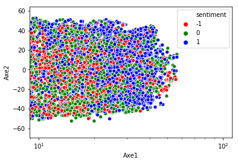

```python
g=sns.scatterplot(x="Axe1", y="Axe2",hue='sentiment',data=data_,palette=color_dict,legend='full')
g.set(xscale="log")
```

```python
tsne_model=TSNE(n_components=2, verbose=1, random_state=0)
tsne_w2v=tsne_model.fit_transform(feat_test)
```

```
[t-SNE] Computing 91 nearest neighbors...
[t-SNE] Indexed 3534 samples in 0.027s...
[t-SNE] Computed neighbors for 3534 samples in 1.711s...
[t-SNE] Computed conditional probabilities for sample 1000 / 3534
[t-SNE] Computed conditional probabilities for sample 2000 / 3534
[t-SNE] Computed conditional probabilities for sample 3000 / 3534
[t-SNE] Computed conditional probabilities for sample 3534 / 3534
[t-SNE] Mean sigma: 0.302225
[t-SNE] KL divergence after 250 iterations with early exaggeration: 82.066612
[t-SNE] KL divergence after 1000 iterations: 2.547659
```

```python
color_dict = dict({-1:'red', 0:'green', 1:'blue'})
data_=pd.DataFrame(data=tsne_w2v, columns=['Axe1','Axe2'])

data_['sentiment']=list(y_test)
data_.head(5)
```

|  | Axe1 | Axe2 | sentiment |
| --- | --- | --- | --- |
| 0 | 5.525988 | -57.667225 | 0 |
| 1 | 24.418699 | 8.228320 | 1 |
| 2 | 11.241199 | -35.936970 | -1 |
| 3 | -13.767161 | 67.399078 | 1 |
| 4 | 2.034173 | -59.920254 | 1 |

```
[None]
```

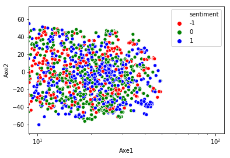

```python
g=sns.scatterplot(x="Axe1", y="Axe2",hue='sentiment',data=data_,palette=color_dict,legend='full')
g.set(xscale="log")
```

# Comment adapter ce cas

Pour l'entraînement de word2Vec:

Certains articles suggère que les représentations des word embeddings reste similaire en passant d'une langue à une autre, on peut tester cette hypothèse pour voir si l'on peut l'exploiter pour le passage en francais.

On peut aussi entraîner notre word embedding sur des articles qui ont un vocabulaire similaire à celui des articles de la revue.